# Afleveirng 8

Lucas Bagge

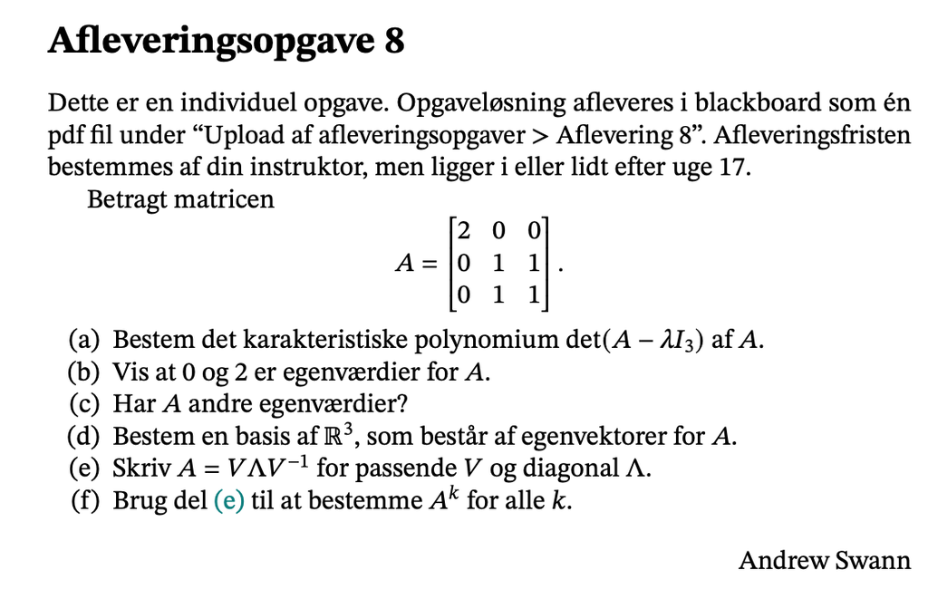

### a)

Vi har følgende matrice:

$$A=
\begin{pmatrix}
2&0&0\\
0&1&1\\
0&1&1
\end{pmatrix}$$

Hvor vi vil bestemme det karakteristisk polynomium så vi følger formlen

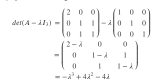

Som er det karakteristisk polynomium for A.

### b)

Nu skal vi vise at 0 og 2 er egenværdier for A. Det kan vi gøre ved at løse det karakteristisk polynomium som vi fandt i opgave a:

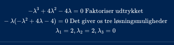

### d)

Nu finder vi egenvektorer.

Vi starter med $\lambda_1=2$

$$A=
\begin{pmatrix}
2-2&0&0\\
0&1-2&1\\
0&1&1-2
\end{pmatrix}$$

$$A=
\begin{pmatrix}
0&0&0\\
0&-1&1\\
0&1&-1
\end{pmatrix}$$

Hvor vi skal finde nul rummet. Her skal vi finde echelon form af ovenstående:

$$
$$\begin{pmatrix}
0&0&0\\
0&-1&1\\
0&1&-1
\end{pmatrix}$$
$$\begin{pmatrix}
0&-1&1\\
0&0&0\\
0&1&-1
\end{pmatrix}$$
$$\begin{pmatrix}
0&1&-1\\
0&0&0\\
0&1&-1
\end{pmatrix}$$
$$\begin{pmatrix}
0&1&-1\\
0&0&0\\
0&0&0
\end{pmatrix}$$

Herefter skal vi løse følgende:

$$\begin{pmatrix}
0&1&-1\\
0&0&0\\
0&0&0
\end{pmatrix}
\begin{bmatrix} x_1\\x_2\\x_3 \end{bmatrix}=
\begin{bmatrix} 0\\0\\0 \end{bmatrix}$$

Det samme gør vi for $\lambda=0$

hvor vi får egenvektoren (går ikke gennem de samme udregninger igen):

$$\begin{bmatrix} 0\\-1\\1\end{bmatrix}$$

I alt er basis således

$$\begin{bmatrix} 1\\0\\0 \end{bmatrix},
\begin{bmatrix} 0\\1\\1\end{bmatrix},
\begin{bmatrix} 0\\-1\\1\end{bmatrix}$$

### e)

V er vores egenvektor matrice:

$$V=
\begin{bmatrix} 1&0&0
\\0&1&-1
\\0&1&1
\end{bmatrix}$$

$\Lambda$ er en diagonal matrice hvor diagonalen består af vores egenværdier.

$$\Lambda=
\begin{bmatrix} 2&0&0
\\0&2&0
\\0&0&0
\end{bmatrix}$$

Således kan vi skrive ud i formlen $V\Lambda V^{-1}$ og se vi får vores A matrice.

$$A=
V\Lambda V^{-1} \\
\begin{bmatrix}
2&0&0\\
0&1&1\\
0&1&1
\end{bmatrix}
= \begin{bmatrix} 1&0&0
\\0&1&-1
\\0&1&1
\end{bmatrix}
\cdot
\begin{bmatrix} 2&0&0
\\0&2&0
\\0&0&0
\end{bmatrix}
\cdot
\begin{bmatrix} 1&0&0
\\0&1&-1
\\0&1&1
\end{bmatrix}^{-1}$$

### f)

Lad M være en kvadratisk matrix. Beregn power af A ved matrix multiplikation

$$A^k=AA...A \text{ Hvor AA..A=k}$$

Hvor vi kan bruge diagonaliserting til at beregne $A^k$

$$A^k=(V\Lambda V^{-1})^k=V\Lambda V^{-1}V \Lambda V^{-1}..V\Lambda V^{-1}=V\Lambda ^KV^{-1}$$